# UML Cours 2 : Diagrammes de classe : héritage

Pierre Gérard

IUT de Villetaneuse

DUT informatique, S2 2013

# Héritage et abstraction et interfaces

## Relation d’héritage

L’héritage une relation de spécialisation/généralisation.

- Les éléments spécialisés héritent de la structure et du comportement des éléments plus généraux (propriétés, associations et autres héritages)
- Exemple : Par héritage d’Article, un livre a d’office un prix, une désignation et une opération acheter(), sans qu’il soit nécessaire de le préciser

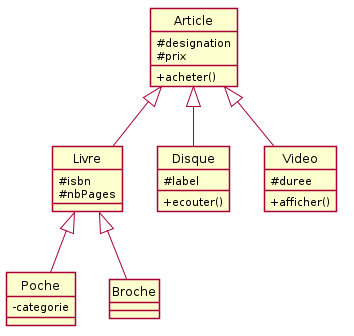

## Héritage en Java

```java
class Livre extends Article {
    ...
}
```

Le mot clé `extends` en Java n’a rien à voir avec le mot clé `extends` en UML, employé en particulier dans les diagrammes de cas d’utilisation.

## Sans héritage

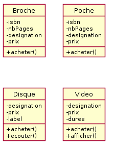

## Héritage des parents

La classe *enfant* (celle qui hérite) possède toutes les propriétés de ses classes *parents* (attributs et opérations)

- La classe enfant est la classe spécialisée (ici Livre)
- La classe parent est la classe générale (ici Article)

## Terminologie

La *signature* d’une opération est constituée de son nom et de ses paramètres (pas de sa valeur de retour).

La *surcharge* d’opérations (même nom, mais signatures des opérations différentes) est possible dans toutes les classes.

*Polymorphisme* :

- Une classe enfant peut *redéfinir* (même signature) une ou plusieurs méthodes de la classe parent
- Un objet utilise en principe la définition la plus spécialisée dans la hiérarchie des classes.

*Substitution* : une instance d’une classe peut être utilisée partout où une instance de sa classe parent est attendue (par exemple, toute opération acceptant un objet d’une classe Animal doit accepter tout objet de la classe Chat (l’inverse n’est pas toujours vrai).

## Classe abstraite

Une opération est dite *abstraite* lorsqu’on connaît sa signature mais pas la manière dont elle peut être réalisée (en UML, on écrit son nom en italique).

- Il appartient aux classes enfant de définir les opérations abstraites.

Une classe est dite *abstraite* lorsqu’elle définit au moins une méthode abstraite ou lorsqu’une classe parent contient une méthode abstraite non encore réalisée (en UML, on écrit son nom en italique).

- Tant qu’au moins une méthode demeure abstraite (même héritée), la classe ne peut être qu’abstraite.

Il est impossible d’instancier directement une classe abstraite.

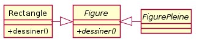

## Héritage multiple

Une classe peut avoir plusieurs classes parents. On parle alors d’*héritage multiple*.

- Le langage C++ est un des langages objet permettant son implantation effective.
- Java ne le permet pas et on doit employer des interfaces.

L’emploi de l’héritage multiple est souvent peu justifié et d’autres solutions de conception sont souvent préférables.

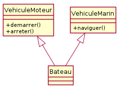

## Interface : utilisation

Les interfaces sont très utilisées en COO et en POO. On les utilise d’ailleurs plus régulièrement que l’héritage, par exemple.

Le rôle d’une interface est de regrouper un ensemble d’opérations assurant un service cohérent que des classes sont susceptibles d’offrir. On peut ainsi définir des classes clientes (ici, `Page`) avant d’avoir défini toutes les implémentations requises de l’interface.

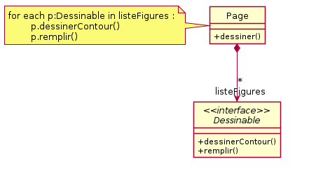

Selon le principe de `substitution`, on pourra employer une classe réalisant une interface partout où l’interface est attendue.

## Interface : définition

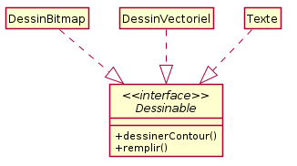

- Une interface est définie comme une classe, avec les mêmes compartiments. On ajoute le stéréotype `<< interface >>` avant le nom de l’interface.
- On utilise une relation de type *réalisation* entre une interface et une classe qui l’implémente (flèche d’héritage en pointillés).
- Les classes implémentant une interface doivent implémenter toutes les opérations décrites dans l’interface.

# Compléments sur les diagrammes de classes

## Associations réflexives

L’association la plus utilisée est l’association binaire (reliant deux classes).

Parfois, les deux extrémités de l’association pointent vers la même classe. Dans ce cas, l’association est dite *réflexive*.

## Instantiation d’associations réflexives

Instanciée, une association réflexive fait intervenir plusieurs objets. Par exemple :

- Un premier objet de classe `Categorie` joue le rôle de `categoriePrincipale`
- Un second objet joue le rôle de `sousCategorie`

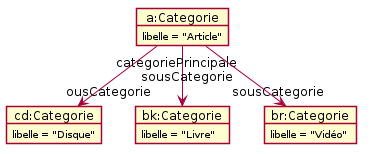

## Associations n-aires

Artité des associations :

Il arrive que ce ne soit pas suffisant. Dans ce cas, on peut définir des relations n-aires.

- Pour déterminer les multiplicités d’un côté, on considère le nombre d’objets liés à un (n-1)-uple quelconque formé d’objets de tous les autres côtés
- Ces associations se rencontrent assez rarement en pratique. Dans la plupart des cas, il est en effet plus pertinent d’utiliser une classe-association.

## Attributs de classe

- Par défaut, les attributs correspondent à des variables d’instance, dont la valeur peut changer pour chaque instance de la classe considérée.
- Les attributs de classe sont des variables dépendant des classes et pas de leurs instances.
  - Graphiquement, un attribut de classe est souligné
  - De tels attributs correspondent aux variables de classe (`static` en Java)

## Opérations de classe

- Une opération de classe est une propriété de la classe, et non de ses instances.
- Elle n’a pas accès aux attributs des objets de la classe.

## Classe paramétrée

Pour définir une classe générique et paramétrable en fonction de valeurs et/ou de types :

- Définition d’une classe paramétrée par des éléments spécifiés dans un rectangle en pointillés
- Utilisation d’une dépendance stéréotypée « bind » pour définir des classes en fonction de la classe paramétrée.

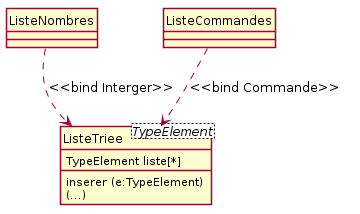

## Paquetages

Il est recommandé de mettre dans des *paquetages (packages)* différents les éléménts qui ont un raport plus étroi les uns avec les autres.

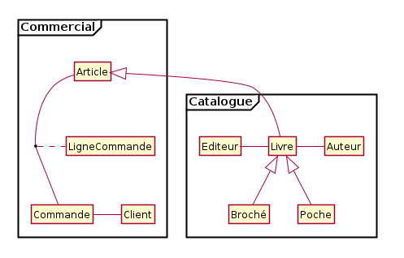

Ici, par exemple, on identifie un package pour les éléments liés aux aspects commerciaux, et un autre pour les éléménts concernant le catalogue de produits.

A la manière de dossiers, on peut imbriquer des packages dans d’autres packages.

Chaque classe dispose d’un nom absolu et non ambigu `Package::SousPackage::NomClasse`. Exemple : `java.lang.String`.

# Impact des associations sur un code en java

## Association unidirectionnelle * vers 1

Ce type d’association est le plus courant, et heureusement le plus simple à impélmenter.

```java
class A {
    private B b;
    (getter et setter publics)
}
```

## Association unidirectionnelle * vers *

[figure not shown]

```java
class A {
    List<B> b;
    (getter, adder et remover publics)
}
```

## Association bididirectionnelle 1 vers 1

```java
public class A {
    private B b;
    public void setB(B b) {
        if ((b!=null) && (b.getA()!=null))  // si b est déjà connecté à un autre A
            b.getA().setB(null);            // cet autre A doit se déconnecter
            this.b=b;
            b.setA(this);
    }
    public B getB() {return(b);}
}
```

Il faut également définir l’opération symétrique dans `B`.

## Association unidirectionnelle vers 1

C’est paradoxalement plus complexe que le cas bidirectionnel :

- Les instances de B ne doivent en principe pas référencer des instances de A
- L’unicité de l’instance de A est donc assez délicate à contrôler

En pratique, on peut réfléchir à la nécessite de la multiplicité maximale de 1 à la source.

Si elle est vraiment justifiée, on peut admettre qu’un développeur code en réalité une association bi-directionnelle et joue sur les modificateurs d’accès pour rendre la relation plus asymétrique.

## Association bidirectionnelle 1 vers *

```java
public class A {
    private List <B> b;
    public A() {this.b = new List<B>(); }
    public List<B> getList() {return(this.b);}
    public void remove(B b){this.b.remove(b);}
    public void addB(B b){
        if(!this.b.contains(b)){
            if (b.getA()!=null) b.getA().remove(b);
            b.setA(this);
            this.b.add(b);
        }
    }
}

public class B {
    private A a;
    public A getA() {return (this.a);}
    public void setA(A a){
        if((a!=null) && (!a.get().contains(this)) {
            if (this.a != null) this.a.remove(this);
            this.setA(a);
            this.a.get().add(this);
        }
    }
}
```

## Association bidirectionnelle * vers *

A faire en exercice pour la prochaine scéance ;)

## Classe association unidirectionnelle * vers 1

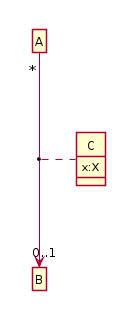

```java
class A {
    private B b;
    private C c;
    (getB, setB et éventuellement getC)
    public getX {return this.x.getX();}
    public setX(x:X) {this.x.setX(x);}
}

class C {
    private X x;
    (getter et setter publics)
}
```

## Classe association unidirectionnelle * vers 1 (plus simple)

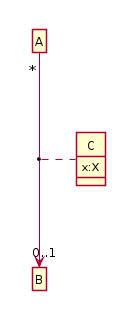

```java
class A {
    private B b;
    private X x;
    (getter et setter publics)
}
```

## Classe association unidirectionnelle * vers *

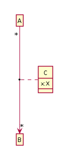

```java
class A {
    private List<C> c;
    (getter et setter publics)
    public getB {return this.c.getB();}
    public setB(b:B) {this.c.setB(b);}
    public getX {return this.c.getX();}
    public setX(x:X) {this.c.setX(x);}
}
class C {
    private B b;
    private X x;
    (getters et setters publics)
}
```

## Classe association bidirectionnelle * vers *

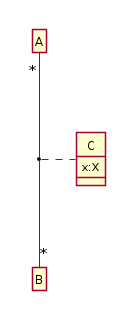

En pratique, on se ramène à un cas comme :

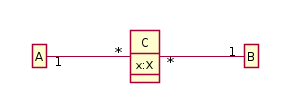

A faire également pour la prochaine scéance ;)

Module d’UML